# 10 Findings

Kanawut Laoritthikrai

December 3, 2017

# Finding 1

Relationship between defaul and age

We can see that people who default are the age between 10 and 60.

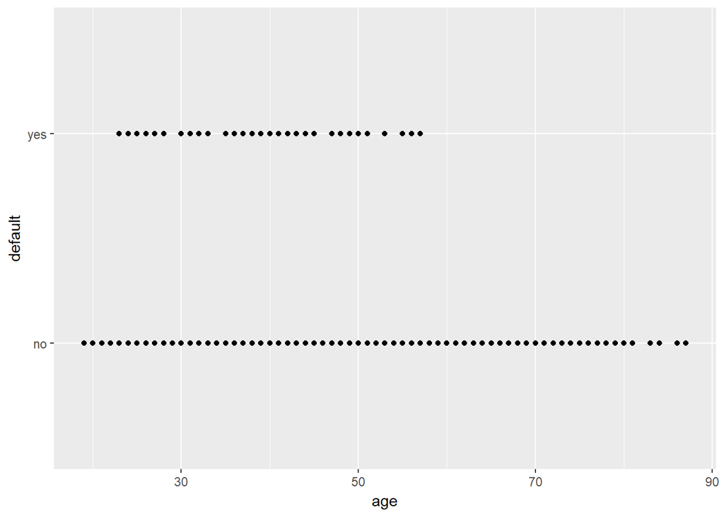

```r
ggplot(bank, aes(age, default)) + geom_point()
```

# Finding 2

Relationship between marital and age

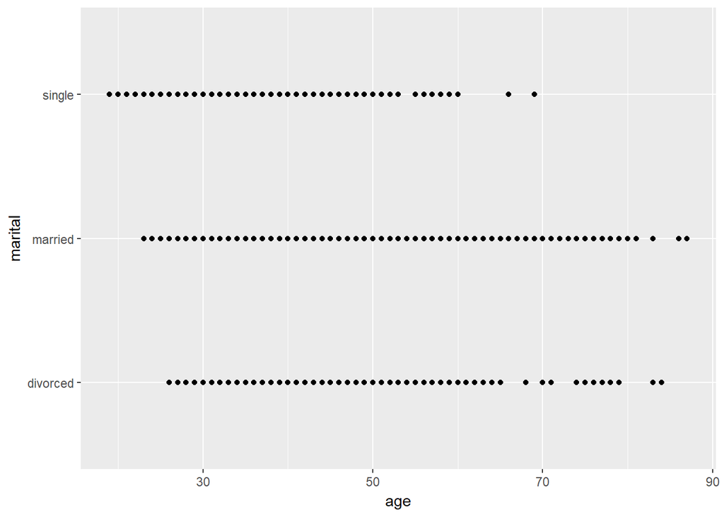

```r
ggplot(bank, aes(age, marital)) + geom_point()
```

# Finding 3

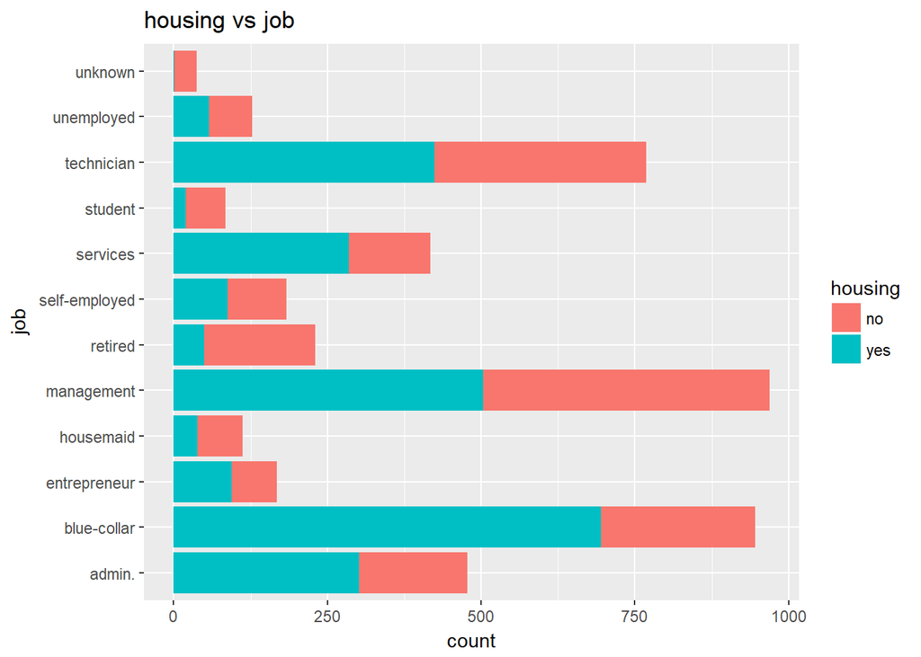

```r
ggplot(bank, mapping = aes(x = job, fill = housing)) +
geom_bar() + coord_flip()+
ggtitle("housing vs job")
```

# Finding 4

Relationship between education and default:

Results show that the customers who default have a good mix of educational backgrounds. However, all of those who default are below 60 years old.

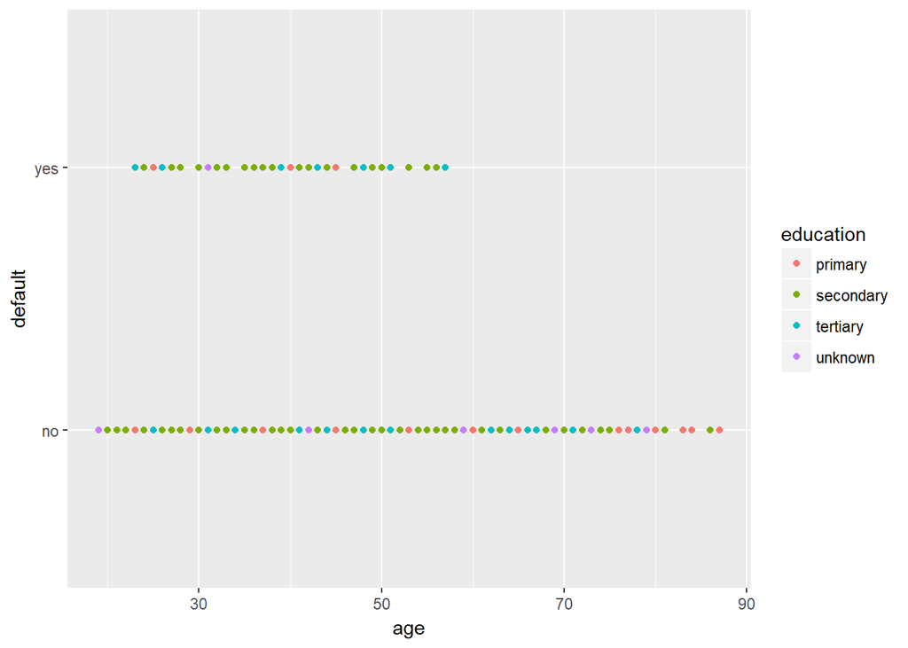

```r
ggplot(bank, aes(x = age, y = default, color = education)) +
geom_point() +theme(legend.position="right")
```

?aes

# Finding 5

Different duration depending on age and by contact group

Telephone using group has shorter duration compared to cellular using group and unknown group.

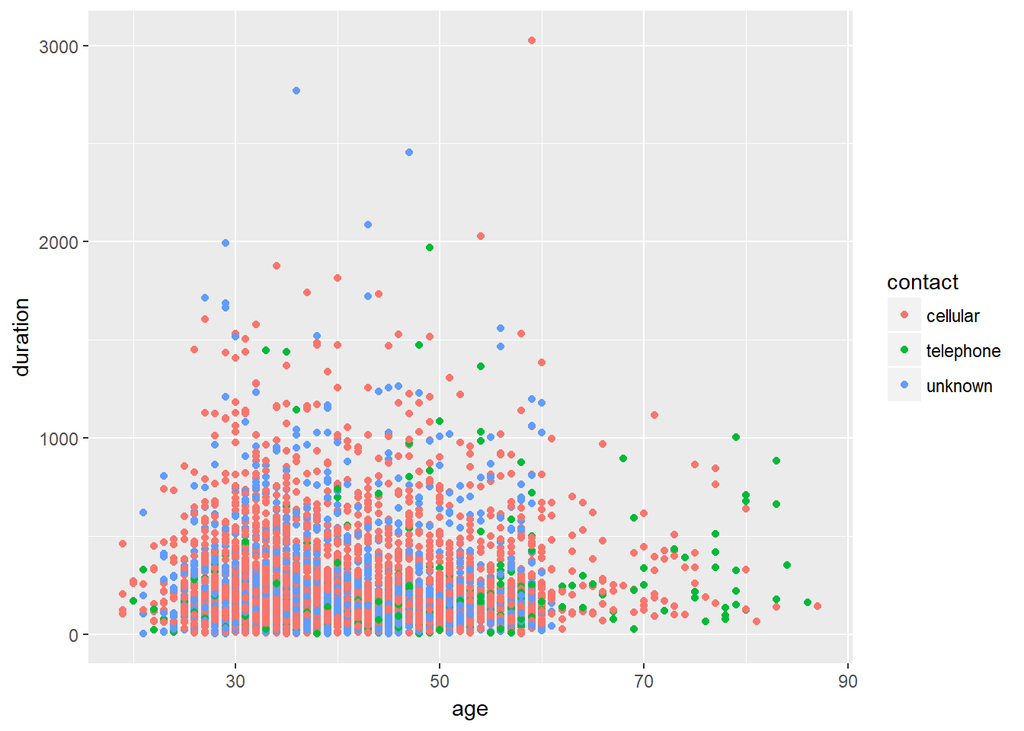

```r
ggplot(bank) + geom_point(aes(age, duration, color = contact))
```

# Finding 6

Relationship between housing and balance

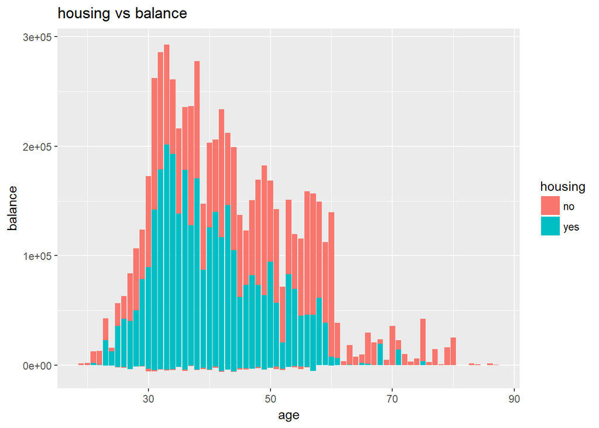

```r
ggplot(bank, aes(age,balance)) +
  geom_bar(aes(fill = housing), stat = "identity") +
  ggtitle("housing vs balance")
```

# Finding 7

marital status in different kind of jobs

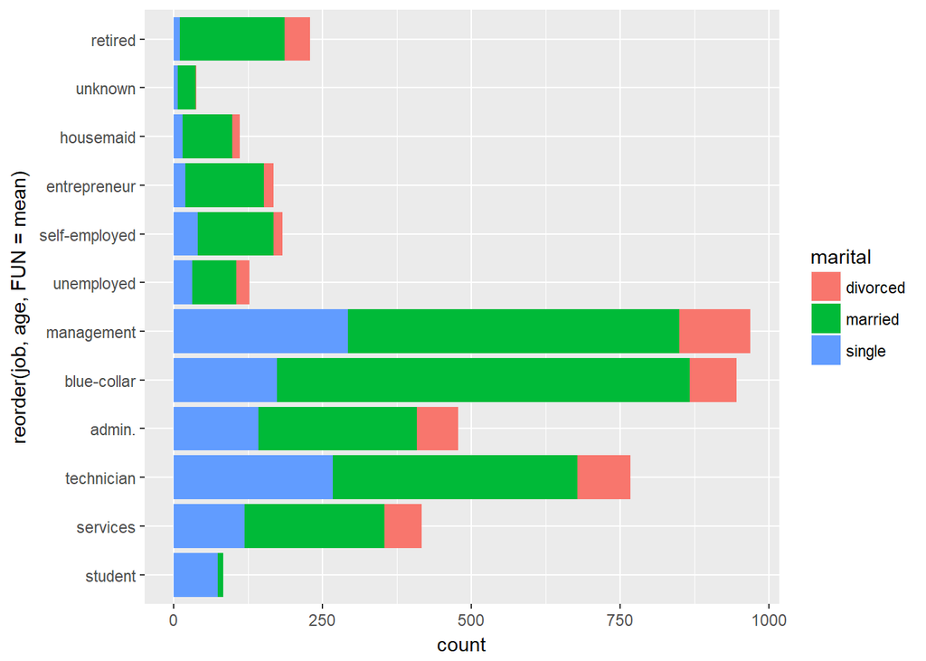

```r
ggplot(data = bank, mapping=aes(x=reorder(job, age, FUN=mean), fill=marital))+
  geom_bar()+coord_flip()
```

# Finding 8

Elder people tend to get lower education but Youngster people receive higher education.

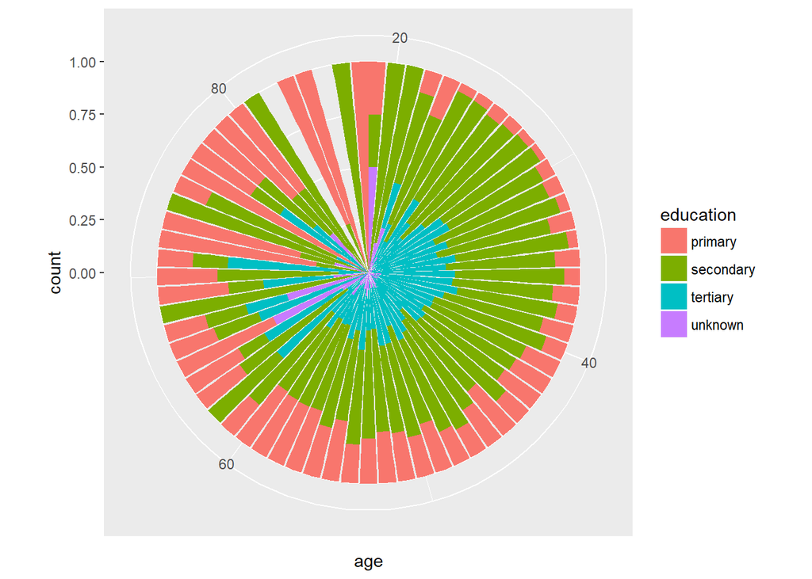

```r
ggplot(bank) +
geom_bar(mapping = aes(x = age, fill = education), position = "fill") +
coord_polar()
```

# Finding 9

Count people in each age groups who have loan and haven’t loan

We can see that elder people (age more than 60) don’t have loan

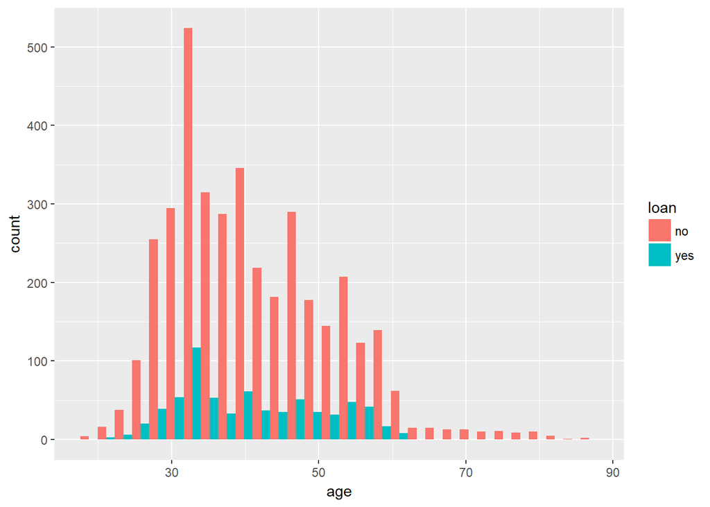

```r
ggplot(bank)+geom_histogram(mapping=aes(x=age,fill=loan), position="dodge")
## `stat_bin()` using `bins = 30`. Pick better value with `binwidth`.
```

# Finding 10

Plot of balance depending on age, grouped by housing and education

primary eudcation with housing group has lowest balance, compared to other groups.

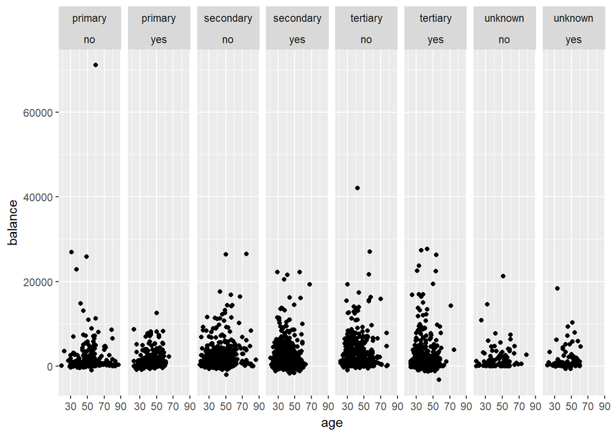

```r
ggplot(data = bank) +
geom_point(mapping = aes(age,balance)) +
facet_wrap(education ~ housing, nrow = 1)
```